As mentioned earlier, two of the variables (sales[job position] and salary) are factors. Salary in particular could quite possibly play a role in time spent with company. I am created dummy variables so the numeric representation can be used in the models.

```r
hrdata2 <- cbind (hrdata, dummy(hrdata$Department), dummy(hrdata$salary))
```

Confirmed that the dummy variables were added. There are now 26 variables.

```r
names(hrdata2)
```

```
 [1] "satisfaction_level"    "last_evaluation"       "number_project"
 [4] "average_montly_hours"  "time_spend_company"    "Work_accident"
 [7] "left"                  "promotion_last_5years" "Department"
[10] "salary"                "leftFactor"            "promoFactor"
[13] "wrkAcdntFactor"        "hrdataaccounting"      "hrdatahr"
[16] "hrdataIT"              "hrdatamanagement"      "hrdatamarketing"
[19] "hrdataproduct_mng"     "hrdataRandD"           "hrdatasales"
[22] "hrdatasupport"         "hrdatatechnical"       "hrdatahigh"
[25] "hrdatalow"             "hrdatamedium"
```

Splitting hrdata2 into train and test data.

I am splitting the data set (hrdata2) into training and testing data. Used the createDataPartition function from the caret package.

```r
set.seed(102)
trainData <- createDataPartition(y = hrdata2$time_spend_company,
                               p = 0.8, list = FALSE)
train <- hrdata2[trainData,]
test <- hrdata2[-trainData,]
```

Confirming the train/test split. I am looking for 80/20.

```r
dim(train)
```

```
[1] 12000    26
```

```r
dim(test)
```

```
[1] 2999   26
```

DATA MODELING

Set up resampling for 10-fold repeated cross validation.

```r
set.seed(100)
tr <- trainControl(method = "repeatedcv", number = 10, repeats = 5)
```

I began by establishing a baseline (more or less) by running linear regression on our data without resampling. From the summary, we see that R2 is 0.08722, F-statistic is 63.61, and nine variables are considered insignificant.

```r
model_lmstat <- lm(time_spend_company~., data=train[,-c(9:13)])
```

```r
summary(model_lmstat)
```

```
Call:
lm(formula = time_spend_company ~ ., data = train[, -c(9:13)])

Residuals:
    Min      1Q  Median      3Q     Max
-3.0176 -0.8161 -0.3179  0.5341  7.2734

Coefficients: (2 not defined because of singularities)
                        Estimate Std. Error t value Pr(>|t|)
(Intercept)            2.1589007  0.0823716  26.209  < 2e-16 ***
satisfaction_level    -0.2317874  0.0576548  -4.020 5.85e-05 ***
last_evaluation        0.6176327  0.0837026   7.379 1.70e-13 ***
number_project         0.1843695  0.0120449  15.307  < 2e-16 ***
average_montly_hours   0.0007804  0.0002918   2.674 0.007499 **
Work_accident          0.0709507  0.0368834   1.924 0.054423 .
left                   0.4863070  0.0336314  14.460  < 2e-16 ***
promotion_last_5years  0.5285472  0.0884963   5.973 2.40e-09 ***
hrdataaccounting       0.0688611  0.0640165   1.076 0.282093
hrdatahr              -0.0379288  0.0650896  -0.583 0.560095
hrdataIT               0.0794515  0.0541224   1.468 0.142132
hrdatamanagement       0.8227547  0.0709967  11.589  < 2e-16 ***
hrdatamarketing        0.1787338  0.0615239   2.905 0.003678 **
hrdataproduct_mng      0.0994923  0.0598298   1.663 0.096354 .
hrdataRandD           -0.0004259  0.0630293  -0.007 0.994608
hrdatasales            0.1346963  0.0389498   3.458 0.000546 ***
hrdatasupport         -0.0121650  0.0450061  -0.270 0.786937
hrdatatechnical               NA         NA      NA       NA
hrdatahigh             0.1004935  0.0498852   2.014 0.043980 *
hrdatalow             -0.1216673  0.0270119  -4.504 6.73e-06 ***
hrdatamedium                  NA         NA      NA       NA
---
Signif. codes:  0 ‘***’ 0.001 ‘**’ 0.01 ‘*’ 0.05 ‘.’ 0.1 ‘ ’ 1

Residual standard error: 1.404 on 11981 degrees of freedom
Multiple R-squared:  0.08722,   Adjusted R-squared:  0.08585
F-statistic: 63.61 on 18 and 11981 DF,  p-value: < 2.2e-16
```

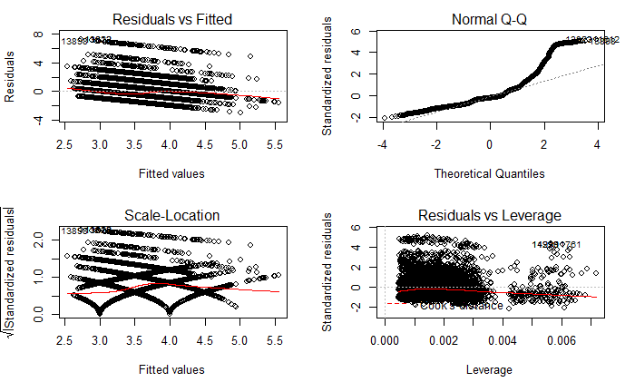

```r
par(mfrow=c(2,2))
plot(model_lmstat)
```

For the first model, I used a linear regression model. From the results, we have a R2 of 0.08515 after resampling and tuning, however the summary of model_lm shows R2 of 0.08722 the same as the non-caret linear regression. In fact, the summary results are identical for model_lmstat and model_lm.

```r
model_lm <- train(time_spend_company ~ ., data = train[,-c(9:13)],
                    method = "lm", trControl = tr, trace = FALSE)
```

[output not shown]

[output cut: 18 more lines]

```r
model_lm$results
```

|  | intercept | RMSE | Rsquared | MAE | RMSESD | RsquaredSD | MAESD |
| --- | --- | --- | --- | --- | --- | --- | --- |
| 1 | TRUE | 1.404438 | 0.08515364 | 0.970549 | 0.04380346 | 0.01665964 | 0.02194482 |

```r
summary(model_lm)
```

```
Call:
lm(formula = .outcome ~ ., data = dat, trace = FALSE)

Residuals:
    Min      1Q  Median      3Q     Max
-3.0176 -0.8161 -0.3179  0.5341  7.2734

Coefficients: (2 not defined because of singularities)
                        Estimate Std. Error t value Pr(>|t|)
(Intercept)            2.1589007  0.0823716  26.209  < 2e-16 ***
satisfaction_level    -0.2317874  0.0576548  -4.020 5.85e-05 ***
last_evaluation        0.6176327  0.0837026   7.379 1.70e-13 ***
number_project         0.1843695  0.0120449  15.307  < 2e-16 ***
average_montly_hours   0.0007804  0.0002918   2.674 0.007499 **
Work_accident          0.0709507  0.0368834   1.924 0.054423 .
left                   0.4863070  0.0336314  14.460  < 2e-16 ***
promotion_last_5years  0.5285472  0.0884963   5.973 2.40e-09 ***
hrdataaccounting       0.0688611  0.0640165   1.076 0.282093
hrdatahr              -0.0379288  0.0650896  -0.583 0.560095
hrdataIT               0.0794515  0.0541224   1.468 0.142132
hrdatamanagement       0.8227547  0.0709967  11.589  < 2e-16 ***
hrdatamarketing        0.1787338  0.0615239   2.905 0.003678 **
hrdataproduct_mng      0.0994923  0.0598298   1.663 0.096354 .
hrdataRandD           -0.0004259  0.0630293  -0.007 0.994608
hrdatasales            0.1346963  0.0389498   3.458 0.000546 ***
hrdatasupport         -0.0121650  0.0450061  -0.270 0.786937
hrdatatechnical               NA         NA      NA       NA
hrdatahigh             0.1004935  0.0498852   2.014 0.043980 *
hrdatalow             -0.1216673  0.0270119  -4.504 6.73e-06 ***
hrdatamedium                  NA         NA      NA       NA
---
Signif. codes:  0 ‘***’ 0.001 ‘**’ 0.01 ‘*’ 0.05 ‘.’ 0.1 ‘ ’ 1

Residual standard error: 1.404 on 11981 degrees of freedom
Multiple R-squared:  0.08722,   Adjusted R-squared:  0.08585
F-statistic: 63.61 on 18 and 11981 DF,  p-value: < 2.2e-16
```

Resampling in the train object: As anticipated the R-squared (0.08515) after resampling is lower than the R-squared from using all the data at once.

```r
model_lm
```

```
Linear Regression

12000 samples
   20 predictor

No pre-processing
Resampling: Cross-Validated (10 fold, repeated 5 times)
Summary of sample sizes: 10800, 10799, 10800, 10799, 10801, 10801, ...
Resampling results:

  RMSE      Rsquared    MAE
  1.404438  0.08515364  0.970549

Tuning parameter 'intercept' was held constant at a value of TRUE
```

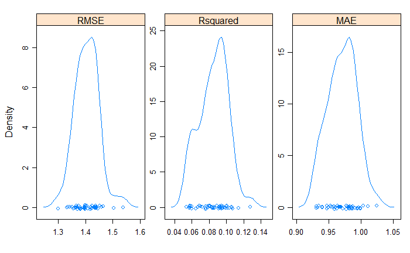

```r
resampleHist(model_lm, type = "density")
```

```r
model_step <- train(time_spend_company ~ ., data = train[,-c(9:13)],
                    preProcess = c("center", "scale"),
                    method = "lmStepAIC", trControl = tr, trace = FALSE)
model_step$results
```

|  | parameter | RMSE | Rsquared | MAE | RMSESD | RsquaredSD | MAESD |
| --- | --- | --- | --- | --- | --- | --- | --- |
| 1 | none | 1.404507 | 0.08448513 | 0.970265 | 0.0474353 | 0.01319925 | 0.02099656 |

```r
summary(model_step)
```

```
Call:
lm(formula = .outcome ~ satisfaction_level + last_evaluation +
    number_project + average_montly_hours + Work_accident + left +
    promotion_last_5years + hrdataIT + hrdatamanagement + hrdatamarketing +
    hrdataproduct_mng + hrdatasales + hrdatahigh + hrdatalow,
    data = dat)

Residuals:
    Min      1Q  Median      3Q     Max
-3.0177 -0.8170 -0.3199  0.5315  7.2628

Coefficients:
                      Estimate Std. Error t value Pr(>|t|)
(Intercept)            3.49800    0.01281 273.021  < 2e-16 ***
satisfaction_level    -0.05793    0.01430  -4.051 5.14e-05 ***
last_evaluation        0.10539    0.01429   7.374 1.77e-13 ***
number_project         0.22817    0.01487  15.344  < 2e-16 ***
average_montly_hours   0.03900    0.01454   2.683  0.00731 **
Work_accident          0.02480    0.01297   1.912  0.05596 .
left                   0.20667    0.01428  14.469  < 2e-16 ***
promotion_last_5years  0.07784    0.01302   5.978 2.33e-09 ***
hrdataIT               0.02183    0.01328   1.644  0.10022
hrdatamanagement       0.16592    0.01347  12.314  < 2e-16 ***
hrdatamarketing        0.04171    0.01319   3.162  0.00157 **
hrdataproduct_mng      0.02401    0.01319   1.821  0.06865 .
hrdatasales            0.06022    0.01368   4.401 1.08e-05 ***
hrdatahigh             0.02825    0.01374   2.056  0.03983 *
hrdatalow             -0.06086    0.01350  -4.510 6.56e-06 ***
---
Signif. codes:  0 ‘***’ 0.001 ‘**’ 0.01 ‘*’ 0.05 ‘.’ 0.1 ‘ ’ 1

Residual standard error: 1.404 on 11985 degrees of freedom
Multiple R-squared:  0.08707,   Adjusted R-squared:  0.086
F-statistic: 81.65 on 14 and 11985 DF,  p-value: < 2.2e-16
```

```r
model_step
```

```
Linear Regression with Stepwise Selection

12000 samples
   20 predictor

Pre-processing: centered (20), scaled (20)
Resampling: Cross-Validated (10 fold, repeated 5 times)
Summary of sample sizes: 10801, 10800, 10800, 10801, 10799, 10799, ...
Resampling results:

  RMSE      Rsquared    MAE
  1.404507  0.08448513  0.970265
```

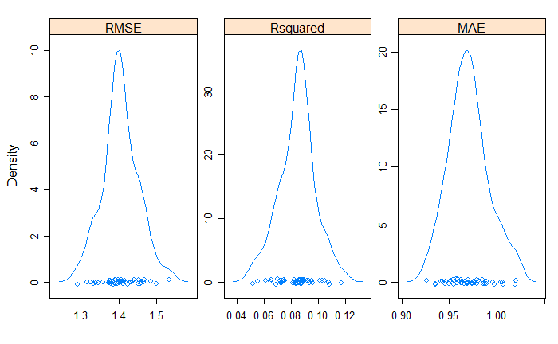

```r
resampleHist(model_step, type = "density")
```

```r
model_glmnet <- train(time_spend_company ~ ., data = train[,-c(9:13)],
                    preProcess = c("center", "scale"),
                    method = "glmnet", trControl = tr)
arrange(model_glmnet$results, RMSE) %>% head
```

|  | alpha | lambda | RMSE | Rsquared | MAE | RMSESD | RsquaredSD | MAESD |
| --- | --- | --- | --- | --- | --- | --- | --- | --- |
| 1 | 0.55 | 0.0058675073 | 1.404234 | 0.08512615 | 0.9705893 | 0.04845815 | 0.01505178 | 0.02239658 |
| 2 | 0.10 | 0.0058675073 | 1.404262 | 0.08511096 | 0.9705283 | 0.04830863 | 0.01509015 | 0.02237051 |
| 3 | 0.10 | 0.0005867507 | 1.404265 | 0.08510868 | 0.9705191 | 0.04830546 | 0.01509103 | 0.02237050 |
| 4 | 0.55 | 0.0005867507 | 1.404267 | 0.08510769 | 0.9704652 | 0.04831650 | 0.01508850 | 0.02237536 |
| 5 | 1.00 | 0.0005867507 | 1.404269 | 0.08510627 | 0.9704587 | 0.04831742 | 0.01508708 | 0.02237602 |
| 6 | 1.00 | 0.0058675073 | 1.404293 | 0.08506013 | 0.9707273 | 0.04860558 | 0.01499481 | 0.02242271 |

```r
model_glmnet$bestTune
```

|  | alpha | lambda |
| --- | --- | --- |
| 5 | 0.55 | 0.005867507 |

Resampling confirmation.

```r
model_glmnet
```

```
glmnet

12000 samples
   20 predictor

Pre-processing: centered (20), scaled (20)
Resampling: Cross-Validated (10 fold, repeated 5 times)
Summary of sample sizes: 10800, 10800, 10801, 10800, 10799, 10799, ...
Resampling results across tuning parameters:

  alpha  lambda        RMSE      Rsquared    MAE
  0.10   0.0005867507  1.404265  0.08510868  0.9705191
  0.10   0.0058675073  1.404262  0.08511096  0.9705283
  0.10   0.0586750729  1.404335  0.08513476  0.9715842
  0.55   0.0005867507  1.404267  0.08510769  0.9704652
  0.55   0.0058675073  1.404234  0.08512615  0.9705893
  0.55   0.0586750729  1.407522  0.08284439  0.9756986
  1.00   0.0005867507  1.404269  0.08510627  0.9704587
  1.00   0.0058675073  1.404293  0.08506013  0.9707273
  1.00   0.0586750729  1.412441  0.07947635  0.9810713

RMSE was used to select the optimal model using the smallest value.
The final values used for the model were alpha = 0.55 and lambda = 0.005867507.
```

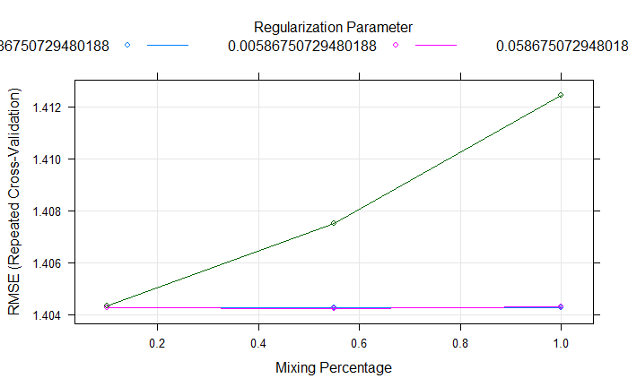

```r
plot(model_glmnet)
```

Model # 4 uses eXtreme Gradient Boosting.

```r
model_xgboost <- train(time_spend_company ~ ., data = train[,-c(9:13)],
                    preProcess = c("center", "scale"),
                    method = "xgbLinear", trControl = tr)
model_xgboost$results
```

|  | lambda | alpha | nrounds | eta | RMSE | Rsquared | MAE | RMSESD | RsquaredSD | MAESD |
| --- | --- | --- | --- | --- | --- | --- | --- | --- | --- | --- |
| 1 | 0e+00 | 0e+00 | 50 | 0.3 | 1.218078 | 0.3135720 | 0.7754721 | 0.05086727 | 0.03670155 | 0.02771294 |
| 4 | 0e+00 | 1e-04 | 50 | 0.3 | 1.219341 | 0.3121018 | 0.7762553 | 0.05083667 | 0.03562262 | 0.02766035 |
| 7 | 0e+00 | 1e-01 | 50 | 0.3 | 1.216906 | 0.3144210 | 0.7756565 | 0.05101107 | 0.03822683 | 0.02743316 |
| 10 | 1e-04 | 0e+00 | 50 | 0.3 | 1.219130 | 0.3123053 | 0.7761496 | 0.05052650 | 0.03498554 | 0.02753710 |
| 13 | 1e-04 | 1e-04 | 50 | 0.3 | 1.218624 | 0.3128529 | 0.7761137 | 0.05183043 | 0.03537653 | 0.02801216 |
| 16 | 1e-04 | 1e-01 | 50 | 0.3 | 1.218146 | 0.3130920 | 0.7763204 | 0.05001422 | 0.03623232 | 0.02701307 |
| 19 | 1e-01 | 0e+00 | 50 | 0.3 | 1.220666 | 0.3102509 | 0.7767109 | 0.05088504 | 0.03551283 | 0.02810866 |
| 22 | 1e-01 | 1e-04 | 50 | 0.3 | 1.221384 | 0.3095456 | 0.7772284 | 0.05116097 | 0.03585265 | 0.02828818 |
| 25 | 1e-01 | 1e-01 | 50 | 0.3 | 1.219461 | 0.3114317 | 0.7759472 | 0.05026129 | 0.03616220 | 0.02728731 |
| 2 | 0e+00 | 0e+00 | 100 | 0.3 | 1.173967 | 0.3668388 | 0.7631559 | 0.05343347 | 0.04143141 | 0.02845860 |

[output cut: 17 more lines]

```r
model_xgboost$bestTune
```

|  | nrounds | lambda | alpha | eta |
| --- | --- | --- | --- | --- |
| 3 | 150 | 0 | 0 | 0.3 |

```r
model_xgboost
```

```
eXtreme Gradient Boosting

12000 samples
   20 predictor

Pre-processing: centered (20), scaled (20)
Resampling: Cross-Validated (10 fold, repeated 5 times)
Summary of sample sizes: 10801, 10801, 10800, 10799, 10800, 10801, ...
Resampling results across tuning parameters:

  lambda  alpha  nrounds  RMSE      Rsquared   MAE
  0e+00   0e+00   50      1.218078  0.3135720  0.7754721
  0e+00   0e+00  100      1.173967  0.3668388  0.7631559
  0e+00   0e+00  150      1.150178  0.3982386  0.7511382
  0e+00   1e-04   50      1.219341  0.3121018  0.7762553
  0e+00   1e-04  100      1.177147  0.3638698  0.7647560
  0e+00   1e-04  150      1.153531  0.3951519  0.7524298
  0e+00   1e-01   50      1.216906  0.3144210  0.7756565
  0e+00   1e-01  100      1.173597  0.3670285  0.7632107
  0e+00   1e-01  150      1.150332  0.3973372  0.7511285
  1e-04   0e+00   50      1.219130  0.3123053  0.7761496
  1e-04   0e+00  100      1.176733  0.3641917  0.7648007
  1e-04   0e+00  150      1.151941  0.3965396  0.7523039
  1e-04   1e-04   50      1.218624  0.3128529  0.7761137
  1e-04   1e-04  100      1.176369  0.3646089  0.7644520
  1e-04   1e-04  150      1.153707  0.3949463  0.7529809
  1e-04   1e-01   50      1.218146  0.3130920  0.7763204
  1e-04   1e-01  100      1.173191  0.3673864  0.7627237
  1e-04   1e-01  150      1.150845  0.3968522  0.7509554
  1e-01   0e+00   50      1.220666  0.3102509  0.7767109
  1e-01   0e+00  100      1.174885  0.3648760  0.7644545
  1e-01   0e+00  150      1.152102  0.3946755  0.7526189
  1e-01   1e-04   50      1.221384  0.3095456  0.7772284
  1e-01   1e-04  100      1.176098  0.3638481  0.7651678
  1e-01   1e-04  150      1.152328  0.3947587  0.7533480
  1e-01   1e-01   50      1.219461  0.3114317  0.7759472
  1e-01   1e-01  100      1.176476  0.3632964  0.7645678
  1e-01   1e-01  150      1.150943  0.3957049  0.7535646

Tuning parameter 'eta' was held constant at a value of 0.3
RMSE was used to select the optimal model using the smallest value.
The final values used for the model were nrounds = 150, lambda = 0, alpha = 0 and eta
 = 0.3.
```

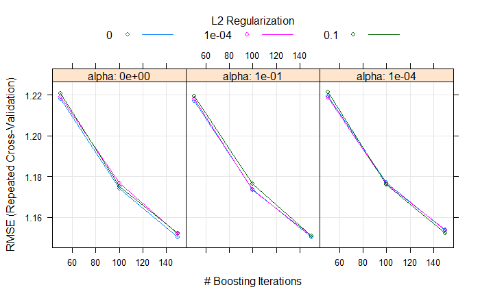

```r
plot(model_xgboost)
```

```r
model_list <- list(lm = model_lm, lmStepAIC = model_step, glm = model_glmnet, xgb = model_xgboost)
res <- resamples(model_list)
summary(res)
```

```
Call:
summary.resamples(object = res)

Models: lm, lmStepAIC, glm, xgb
Number of resamples: 50

MAE
            Min. 1st Qu. Median   Mean 3rd Qu.   Max. NA's
lm        0.9303  0.9564 0.9699 0.9705  0.9853 1.0240    0
lmStepAIC 0.9262  0.9577 0.9690 0.9703  0.9802 1.0200    0
glm       0.9161  0.9551 0.9699 0.9706  0.9874 1.0090    0
xgb       0.7034  0.7282 0.7496 0.7511  0.7746 0.8214    0

RMSE
           Min. 1st Qu. Median  Mean 3rd Qu.  Max. NA's
lm        1.298   1.375  1.400 1.404   1.434 1.539    0
lmStepAIC 1.292   1.378  1.401 1.405   1.432 1.532    0
glm       1.308   1.374  1.398 1.404   1.438 1.506    0
xgb       1.037   1.107  1.142 1.150   1.199 1.268    0

Rsquared
             Min. 1st Qu.  Median    Mean 3rd Qu.   Max. NA's
lm        0.05380 0.07590 0.08605 0.08515 0.09550 0.1280    0
lmStepAIC 0.05195 0.07482 0.08602 0.08449 0.09121 0.1174    0
glm       0.05735 0.07646 0.08310 0.08513 0.09378 0.1236    0
xgb       0.30270 0.37080 0.39840 0.39820 0.42140 0.5248    0
```

MODEL ASSESSMENT

Model_xgboost has the highest R2 and lowest RMSE. Find predictions using the xgboost model.

```r
pred_values <- predict(model_xgboost,test[,-c(9:13)])
```

Plotting the observed values versus the predicted values.

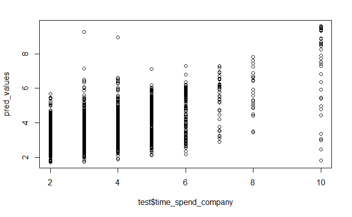

```r
plot(test$time_spend_company,pred_values)
```

The following are the variable importance for the model_xgboost. Although number_project had the highest correlation with time_spend_company, the xgboost model used satisfaction_level the most.

```r
varImp(model_xgboost)
```

```
xgbLinear variable importance

                        Overall
satisfaction_level    100.00000
average_montly_hours   79.51896
last_evaluation        70.96393
left                   35.73867
number_project         23.92924
hrdatamanagement       15.44563
hrdatasales             6.16231
hrdatalow               5.23848
Work_accident           4.97993
hrdatahigh              4.93960
hrdataIT                3.52672
hrdataaccounting        3.03788
promotion_last_5years   2.45513
hrdatasupport           2.15707
hrdatamedium            1.97722
hrdatatechnical         1.97687
hrdatamarketing         1.81142
hrdataproduct_mng       0.91835
hrdatahr                0.04247
hrdataRandD             0.00000
```

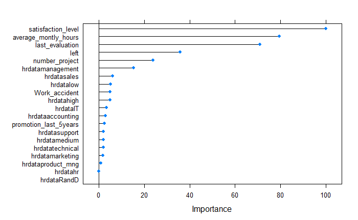

```r
plot(varImp(model_xgboost))
```

Plotted a 3-d graph to illustrate the relationship between time_spend_company, satisfaction_level and average_montly_hours.

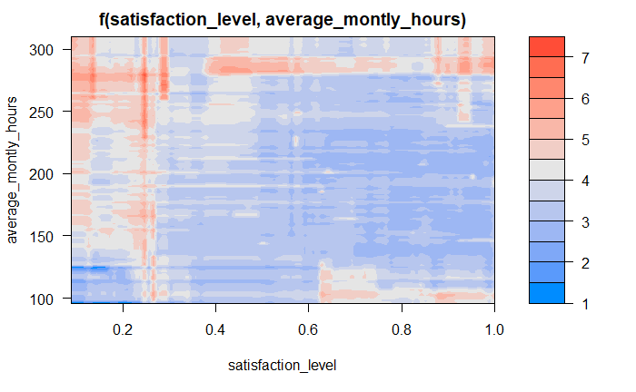

```r
visreg2d(model_xgboost, "satisfaction_level", "average_montly_hours", plot.type="image" )
```

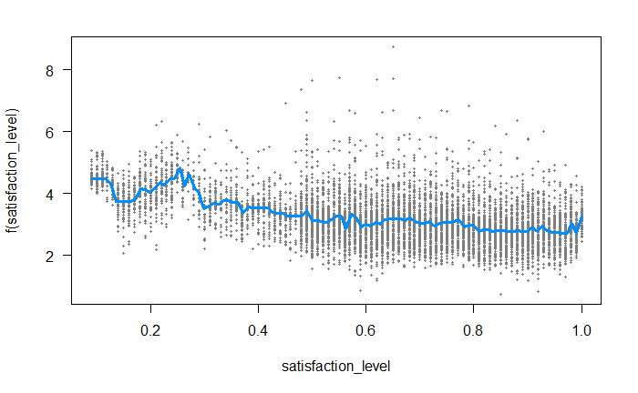

```r
visreg(model_xgboost, "satisfaction_level")
```

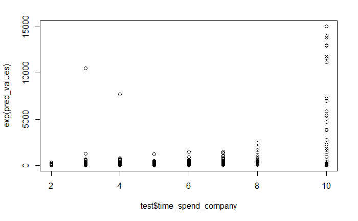

```r
par(mfrow=c(1,1))
plot(test$time_spend_company, exp(pred_values))
```